# Mid-Term_Exam

Celijah

10/24/2019

## 1. Remove all records with missing measurements from the dataset.

```r
#Import Packages
library(tidyverse)
library(factoextra)
library(ISLR)
library(flexclust)
library(dplyr)
library(caret)
library(imputeTS)
#Read Data
university <- read.csv("C:/Users/Stan/Documents/Universities.csv")
Uni_all <- read.csv("C:/Users/Stan/Documents/Universities.csv")

# A. Response:
# remove rows with missing measurement from Universities dataset.
university <- na.omit(university)
Clean_Uni <- university
```

## B. For all the continuous measurements, run K-Means clustering. Make sure to normalize the measurements. How many clusters seem reasonable for describing these data? What was your optimal K?

```r
#Data Preprocessing
library(ggplot2)
set.seed(123)
norm <- preProcess(university[, c(4, 5, 6, 7, 8, 9, 10, 11, 12, 13, 14, 15, 16, 17, 18, 19, 20)], method=c("center", "scale"))

norm_Tufts <- preProcess(university[, c(4, 5, 6, 7, 8, 9, 11, 12, 13, 14, 15, 16, 17, 18, 19, 20)], method=c("center", "scale"))

university[, c(4, 5, 6, 7, 8, 9, 10, 11, 12, 13, 14, 15, 16, 17, 18, 19, 20)] <- predict(norm, university[, c(4, 5, 6, 7, 8, 9, 10, 11, 12, 13, 14, 15, 16, 17, 18, 19, 20)])
```

# Runing K-means clustering on continuous Variables to determine the number of cluster that seems reasonable and optimal k.

Answer: At this point, the optimal choice is 5 as can be seen from the plot below, cluster 15 is too crownded so cluster 5 looks better. See graphs below for evident. Note: This is not the final optimal k

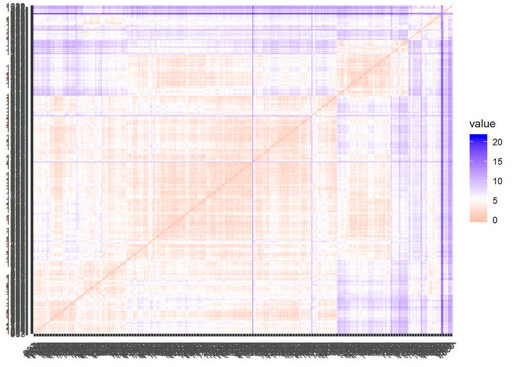

```r
#Steps in determining the optimal k: Install and run needed packages
#install.packages("NbClust")
library(factoextra) # clustering & visualization
library(NbClust)
library(tidyverse)  # data manipulation
library(ISLR)

# Compute clustering algorithm (e.g., k-means clustering) for different values of k. For instance, by varying k from 1 to 10 clusters.

#Plotting and Summarizing Data to Identify Potential Clusters
set.seed(123)
uni_con <- university[, c(4, 5, 6, 7, 8, 9, 10, 11, 12, 13, 14, 15, 16, 17, 18, 19, 20)]
distance <- get_dist(uni_con)
fviz_dist(distance)
```

```r
#Defining the algorithmn for k of 10 and 15
set.seed(123)
k5 <- kmeans(uni_con, centers = 5, nstart = 25)
k15 <- kmeans(uni_con, centers = 15, nstart = 25)
```

```r
#Getting the Size and Center for the Clusters
set.seed(123)
k5$centers
```

```
##   X..appli..rec.d X..appl..accepted X..new.stud..enrolled
## 1       0.1682069         0.2029277            0.37049207
## 2      -0.3426507        -0.2983104           -0.37339353
## 3      -0.5569125        -0.5531207           -0.54647592
## 4       0.5133052         0.1878958            0.04207847
## 5       2.3016968         2.5572926            2.69693471
##   X..new.stud..from.top.10. X..new.stud..from.top.25. X..FT.undergrad
## 1                -0.5783497                -0.4956370      0.44673975
## 2                 0.1396486                 0.2637985     -0.39038553
## 3                -0.6251217                -0.7320661     -0.52891250
## 4                 1.7941218                 1.5251765     -0.07715163
## 5                 0.2040698                 0.3588871      2.72119433
##   X..PT.undergrad in.state.tuition out.of.state.tuition       room
## 1       0.3577778       -1.2804094           -1.0816909 -0.4494664
## 2      -0.2741592        0.5591155            0.4758599  0.1946075
## 3      -0.2502879       -0.2224986           -0.4869970 -0.4735431
## 4      -0.3735320        1.5152395            1.7021870  1.2108424
## 5       1.8684008       -1.0036600           -0.4071160  0.0603682
##         board  add..fees estim..book.costs estim..personal.. X..fac..w.PHD
## 1 -0.71584374  0.5456475       -0.02813158        0.37150911     0.0713757
## 2  0.39150003 -0.1345900       -0.12879063       -0.30974761     0.3363365
## 3 -0.41288238 -0.4013105       -0.04908761        0.07727633    -1.0623362
## 4  1.03863100  0.1320633        0.33234082       -0.47423704     1.0915826
## 5 -0.09220051  0.6367769        0.23336269        0.89689582     0.7545890
##   stud..fac..ratio Graduation.rate
## 1       1.00678771      -0.6683725
## 2      -0.27596976       0.4447424
## 3       0.06652033      -0.5386811
## 4      -1.16554722       1.1647914
## 5       0.49690676      -0.1397266
```

```r
k5$centers
```

```
##   X..appli..rec.d X..appl..accepted X..new.stud..enrolled
## 1       0.1682069         0.2029277            0.37049207
## 2      -0.3426507        -0.2983104           -0.37339353
## 3      -0.5569125        -0.5531207           -0.54647592
## 4       0.5133052         0.1878958            0.04207847
## 5       2.3016968         2.5572926            2.69693471
##   X..new.stud..from.top.10. X..new.stud..from.top.25. X..FT.undergrad
## 1                -0.5783497                -0.4956370      0.44673975
## 2                 0.1396486                 0.2637985     -0.39038553
## 3                -0.6251217                -0.7320661     -0.52891250
## 4                 1.7941218                 1.5251765     -0.07715163
## 5                 0.2040698                 0.3588871      2.72119433
##   X..PT.undergrad in.state.tuition out.of.state.tuition       room
## 1       0.3577778       -1.2804094           -1.0816909 -0.4494664
## 2      -0.2741592        0.5591155            0.4758599  0.1946075
## 3      -0.2502879       -0.2224986           -0.4869970 -0.4735431
## 4      -0.3735320        1.5152395            1.7021870  1.2108424
## 5       1.8684008       -1.0036600           -0.4071160  0.0603682
##         board  add..fees estim..book.costs estim..personal.. X..fac..w.PHD
## 1 -0.71584374  0.5456475       -0.02813158        0.37150911     0.0713757
## 2  0.39150003 -0.1345900       -0.12879063       -0.30974761     0.3363365
## 3 -0.41288238 -0.4013105       -0.04908761        0.07727633    -1.0623362
## 4  1.03863100  0.1320633        0.33234082       -0.47423704     1.0915826
## 5 -0.09220051  0.6367769        0.23336269        0.89689582     0.7545890
##   stud..fac..ratio Graduation.rate
## 1       1.00678771      -0.6683725
## 2      -0.27596976       0.4447424
## 3       0.06652033      -0.5386811
## 4      -1.16554722       1.1647914
## 5       0.49690676      -0.1397266
```

```r
k15$size
```

```
##  [1] 33 43 13 59 23 35  1 13 54  1 41 61 44  8 42
```

```r
k15$size
```

```
##  [1] 33 43 13 59 23 35  1 13 54  1 41 61 44  8 42
```

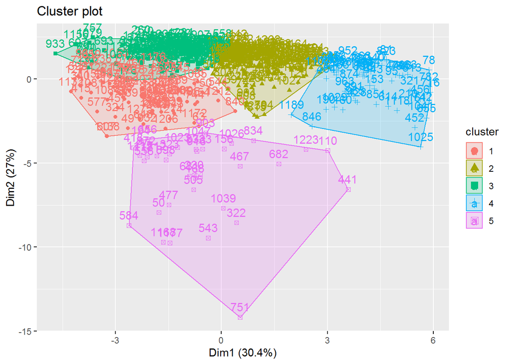

```r
#Visualizing the Clusters
set.seed(123)
fviz_cluster(k5, data = uni_con)
```

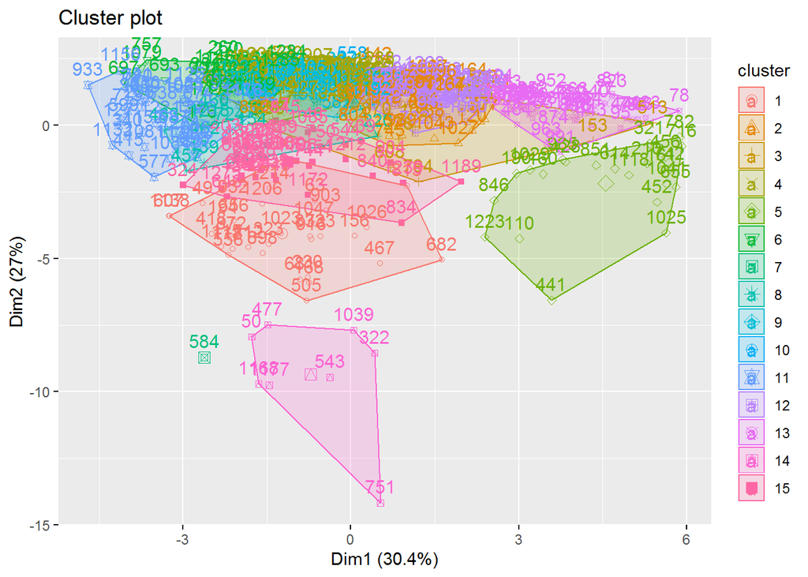

```r
fviz_cluster(k15, data = uni_con)
```

```r
#Using Other Distances
set.seed(123)
k5_median = kcca(uni_con, k=5, kccaFamily("kmedians"))
k15_median = kcca(uni_con, k=15, kccaFamily("kmedians"))
```

```r
#Creating the cluster index
set.seed(123)
clusters_index_5 <- predict(k5_median)
clusters_index_15 <- predict(k15_median)
dist(k5_median@centers)
```

```
##          1        2        3        4
## 2 3.683182
## 3 2.485730 2.371454
## 4 6.771487 3.433428 5.579797
## 5 3.986687 5.229938 5.389279 6.759663
```

```r
dist(k15_median@centers)
```

```
##           1        2        3        4        5        6        7        8
## 2  4.343238
## 3  2.615361 5.869118
## 4  2.524970 3.441297 4.283159
## 5  3.496674 2.815780 5.235634 2.938243
## 6  7.149436 6.134865 7.140742 6.342297 7.672035
## 7  5.243694 8.454019 3.938433 6.742444 8.410963 7.650042
## 8  4.277154 1.990883 5.881272 3.735153 1.655438 7.150852 8.821217
## 9  3.580643 3.793581 5.679769 3.338735 1.877438 8.387965 8.504995 2.733159
## 10 2.572545 3.867193 4.212953 3.166230 2.111279 8.399972 7.498117 3.250217
## 11 6.688018 4.414785 7.309467 5.583031 6.268991 2.831485 8.792556 5.538723
## 12 4.313379 2.000813 5.373032 3.314849 3.801469 4.726596 7.642738 3.325223
## 13 5.231813 2.938534 6.363785 4.323514 4.467133 4.215350 8.317127 3.671189
## 14 4.190940 1.885889 5.684920 3.332733 2.668607 5.690412 8.257431 1.933449
## 15 3.544652 4.305712 5.401514 3.913178 2.093322 8.986925 8.451296 2.998279
##           9       10       11       12       13       14
## 2
## 3
## 4
## 5
## 6
## 7
## 8
## 9
## 10 2.696679
## 11 6.992231 7.364858
## 12 4.646406 4.682404 3.079405
## 13 5.036708 5.701755 2.189455 2.084606
## 14 3.331576 4.056794 3.908689 2.004838 1.966472
## 15 2.086670 2.077026 7.750664 5.190208 5.814228 4.022132
```

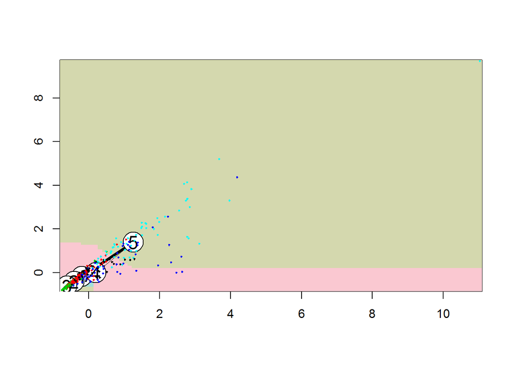

```r
#Cluster Map K5
image(k5_median)
points(uni_con, col=clusters_index_5, pch=10, cex=0.3)
```

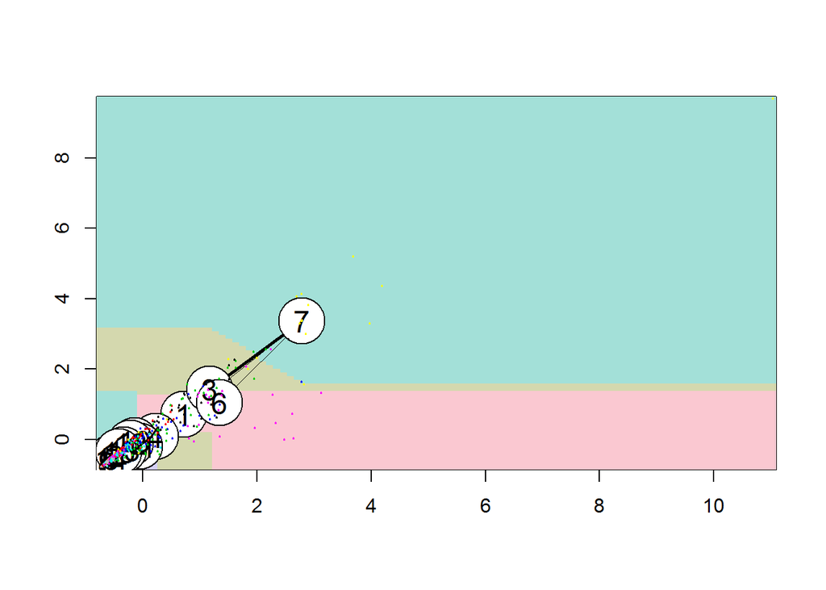

```r
#Cluster Map K15
image(k15_median)
points(uni_con, col=clusters_index_15, pch=20, cex=0.3)
```

Answer: This graph below shows that k=5 was not the best choice afterall, rather 3 is the best and overall choice. Answer optimal k=3

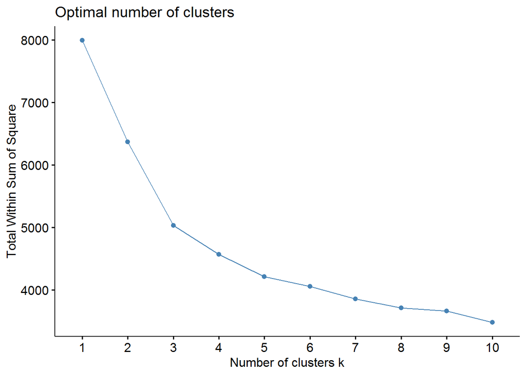

```r
#Testing Whether Our K was Optimal
set.seed(123)
#Scaling the dataframe z-score
fviz_nbclust(uni_con, kmeans, method = "wss")
```

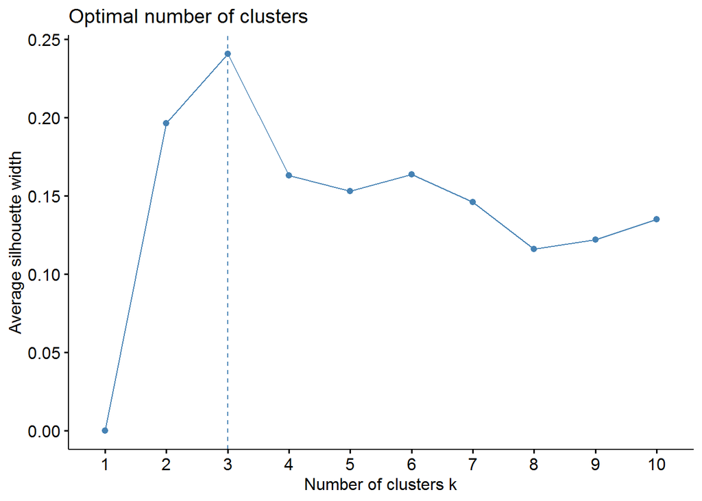

```r
#Scaling the dataframe silhoutte method
fviz_nbclust(uni_con, kmeans, method = "silhouette")
```

```r
#Creating the cluster index for 3 clusters
set.seed(123)
k3_median = kcca(uni_con, k=3, kccaFamily("kmedians"))
clusters_index_3 <- predict(k3_median)
```

```r
#Merging the clusters to the original data frame
set.seed(123)
clusters <- data.frame(clusters_index_3)
clean_Uni <- cbind(Clean_Uni, clusters)
clean_Uni$room_board_fees <- clean_Uni$room + clean_Uni$board + clean_Uni$add..fees + clean_Uni$estim..book.costs + clean_Uni$estim..personal..
```